# Practical Machine Learning

Aakarsh

Monday, August 24, 2014

This writeup illustrates the step by step process followed in building the model and predicting the test outputs.

## Data Import and EDA

The training and test datasets were downloaded to local directory

The training and test data had the following dimensions:

```r
#Training
dim(training)
```

```
## [1] 6038  160
```

```r
#Test
dim(test)
```

```
## [1]  20 160
```

The training data had multiple columns with NA’s and Null values. All these columns were removed to firstly reduce the prediction variable pool and also to ensure garbage variables

The training data showed the following three levels for the “classe” variable

```r
levels(training4$classe)
```

```
## [1] ""  "A" "B"
```

```r
table(training4$classe)
```

```
##
##         A    B
##    1 5580  457
```

To remove the record with “Null” as level , i performed the following operation

```r
training5 <- training4
training5$classe <- as.character(training4$classe)
training6<- training5[which(training5$classe=="A"),]
training6b <- training5[which(training5$classe=="B"),]
training7<- rbind(training6,training6b)
```

This completed the treatment for training data. A similar set of operations were performed for the test data to have only the relevant set of variables

```r
#c and c1 were defined during the training treatment
test2 <- test[,c]
test3 <- test2[,c1]
test4 <- test3[,-c(1,2,3,4,48)]
```

## Model building

Density graphs were plotted to check the distribution of data

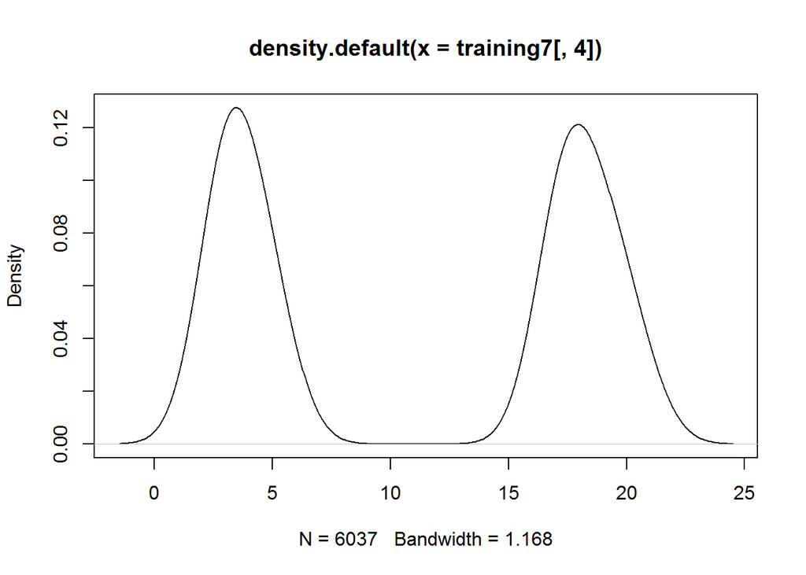

```r
plot(density(training7[,4]))
```

As random forest classification does not demand for variable center and scaling, this process was eliminated.

The **random forest** model was then created using the commands below and the model was applied to the test dataset to arrive at the predictions.

```r
library(randomForest)
model <- randomForest(as.factor(classe) ~ .,data = training7)
predictions <- predict(model,test4)
```

The model stats are as follows:

```r
# type
model$type
```

```
## [1] "classification"
```

```r
#mean decrease in Gini Index (sample only)
head(model$importance)
```

```
##                  MeanDecreaseGini
## roll_belt                  12.405
## pitch_belt                 19.593
## yaw_belt                   11.600
## total_accel_belt           13.761
## gyros_belt_x               37.302
## gyros_belt_y                6.289
```

```r
#number of trees grown
model$ntree
```

```
## [1] 500
```

```r
#number of predictors sampled for spliting at each node
model$mtry
```

```
## [1] 6
```

```r
# vector error rates of the prediction on the input data (sample only)
head(model$err.rate)
```

```
##           OOB        A       B
## [1,] 0.017647 0.007346 0.14286
## [2,] 0.014971 0.007803 0.10182
## [3,] 0.013550 0.007678 0.08683
## [4,] 0.011420 0.005740 0.08267
## [5,] 0.008481 0.003787 0.06634
## [6,] 0.008484 0.004015 0.06323
```

```r
#number of times cases are 'out-of-bag' (sample only)
head(model$oob.times)
```

```
## [1] 177 181 175 191 167 182
```

```r
#confusion matrix
model$confusion
```

```
##      A   B class.error
## A 5580   0    0.000000
## B    3 454    0.006565
```

This concludes the assignment activity